# Dragon Ball Unsupervised Learning

## Model Evaluation

### Silhoutte Score

```python
models_ = [model_kmeans, model_kmedoids, model_agg, model_dbs]

for i in models_:
  try:
    score = silhouette_score(data_scaled, i.predict(data_scaled))
  except:
    score = silhouette_score(data_scaled, i.labels_)
  print(f"The {i} model's score is {score}.")
```

```
The KMeans(n_clusters=3) model's score is 0.43954125532245714.
The KMedoids(n_clusters=3, random_state=1) model's score is -0.2258735047206541.
The AgglomerativeClustering(linkage='complete', n_clusters=3) model's score is 0.46827933604584043.
The DBSCAN(eps=4, min_samples=3) model's score is 0.5494953383950877.
```

Choose the highest soulette score

[output not shown]

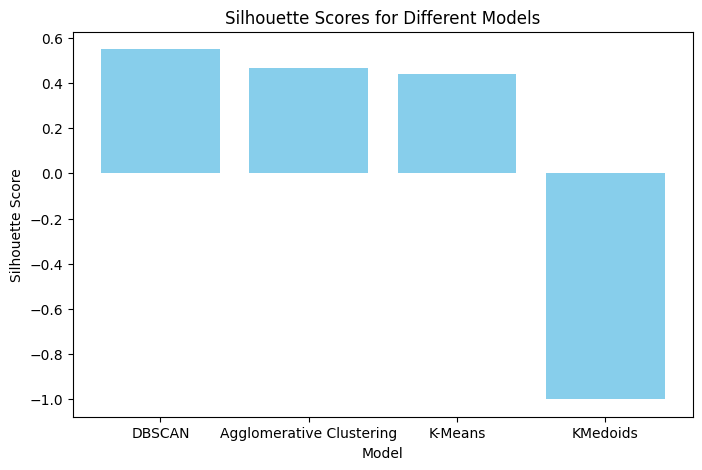

```python
# Store models and their names
models_ = [model_kmeans, model_kmedoids, model_agg, model_dbs]
model_names = ["K-Means", "KMedoids", "Agglomerative Clustering", "DBSCAN"]

# List to store scores
scores = []

# Calculate silhouette scores
for model, name in zip(models_, model_names):
    try:
        labels = model.predict(data_scaled)
    except:
        labels = model.labels_

    unique_labels = np.unique(labels)

    if len(unique_labels) > 1:  # Silhouette Score requires at least 2 clusters
        score = silhouette_score(data_scaled, labels)
    else:
        score = -1  # Invalid clustering case

    scores.append((name, score))

# Sort models by silhouette score (Descending)
scores.sort(key=lambda x: x[1], reverse=True)

# Print ranked models
print("\n🔹 **Ranked Models by Silhouette Score** 🔹")
for rank, (name, score) in enumerate(scores, start=1):
    print(f"{rank}. {name} → Silhouette Score: {score:.4f}")

# Plot silhouette scores
plt.figure(figsize=(8, 5))
plt.bar([x[0] for x in scores], [x[1] for x in scores], color="skyblue")
plt.xlabel("Model")
plt.ylabel("Silhouette Score")
plt.title("Silhouette Scores for Different Models")
plt.show()
```

- Given the best silhouette score, DBSCAN is the preferred method. However, K-Means might still be useful if the dataset is well-separated.

Silhouette Score Distribution Plot

```python
from sklearn.metrics import silhouette_samples

def plot_silhouette(model, data, model_name):
    try:
        labels = model.predict(data)
    except:
        labels = model.labels_

    unique_labels = np.unique(labels)

    if len(unique_labels) > 1:  # Only plot if there are at least 2 clusters
        silhouette_vals = silhouette_samples(data, labels)
        y_lower, y_upper = 0, 0
        plt.figure(figsize=(8, 5))

        for i, cluster in enumerate(np.unique(labels)):
            cluster_silhouette_vals = silhouette_vals[labels == cluster]
            cluster_silhouette_vals.sort()
            y_upper += len(cluster_silhouette_vals)

            plt.fill_betweenx(np.arange(y_lower, y_upper), 0, cluster_silhouette_vals)
            plt.text(-0.05, y_lower + 0.5 * len(cluster_silhouette_vals), str(cluster))
            y_lower = y_upper

        plt.axvline(np.mean(silhouette_vals), linestyle="--", color="red")
        plt.xlabel("Silhouette Score")
        plt.ylabel("Cluster")
        plt.title(f"Silhouette Plot for {model_name}")
        plt.show()
```

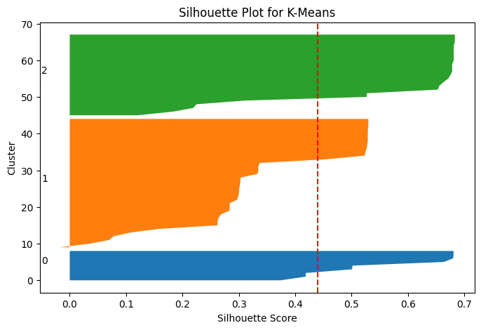

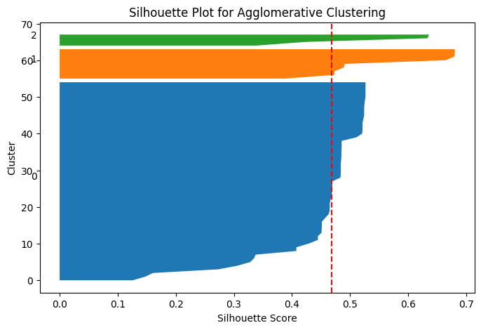

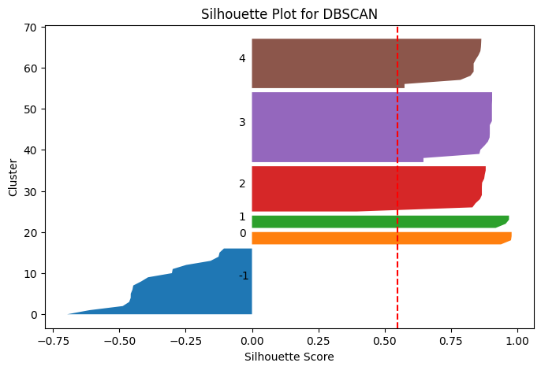

```python
for model, name in zip(models_, model_names):
    plot_silhouette(model, data_scaled, name)
```

t-SNE 2D Projection with Cluster Labels

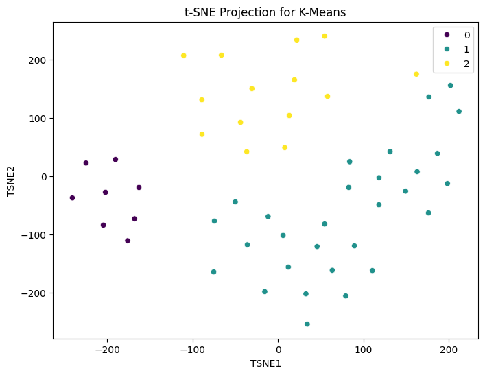

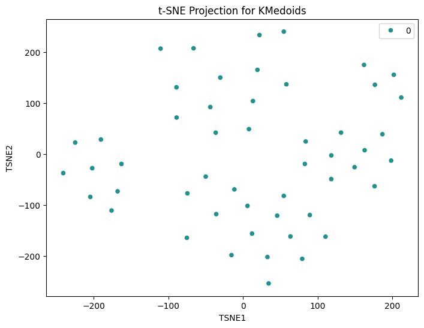

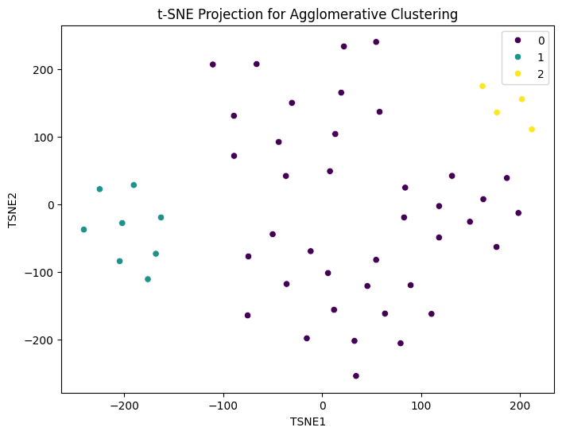

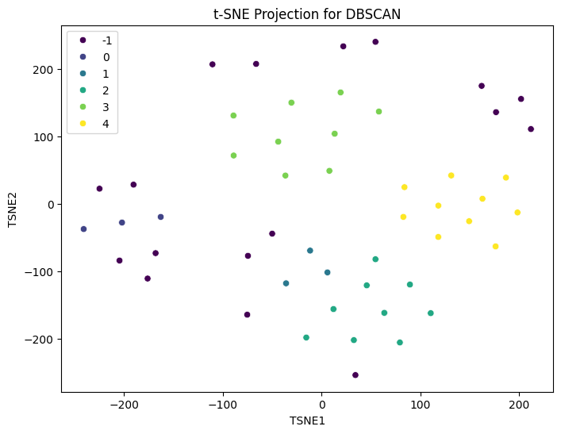

```python
from sklearn.manifold import TSNE

# Apply t-SNE to reduce dimensions to 2D for visualization
tsne = TSNE(n_components=2, random_state=1)
data_tsne = tsne.fit_transform(data_scaled)

# Convert to DataFrame
df_tsne = pd.DataFrame(data_tsne, columns=["TSNE1", "TSNE2"])

# Plot t-SNE for each model
for model, name in zip(models_, model_names):
    try:
        labels = model.predict(data_scaled)
    except:
        labels = model.labels_

    plt.figure(figsize=(8, 6))
    sns.scatterplot(x=df_tsne["TSNE1"], y=df_tsne["TSNE2"], hue=labels, palette="viridis")
    plt.title(f"t-SNE Projection for {name}")
    plt.show()
```

## Insights from Clustering Methods

K-Means

- Pros: Works well when clusters are spherical and evenly sized.
- Cons: Sensitive to initialization and outliers.

K-Medoids

- Pros: More robust to outliers than K-Means.
- Cons: Slower for large datasets.

Agglomerative Hierarchical Clustering

- Pros: Can work well without specifying cluster numbers beforehand.
- Cons: Computationally expensive for large datasets.

DBSCAN

- Pros: Can identify arbitrary-shaped clusters and works well with noise.
- Cons: Requires tuning eps and min_samples.

```python
# # google

# path_ipynb = '/content/drive/MyDrive/My DS DA/Dragon Ball Z/2 Unsupervised Learning.ipynb'
# notebook_path = path_ipynb

# !jupyter nbconvert --to html "{notebook_path}"

# from google.colab import files
# path_html = '/content/drive/MyDrive/My DS DA/Dragon Ball Z/2 Unsupervised Learning.html'

# files.download(path_html)
```